# Prediction of SARS-CoV-2 Epitopes

```r
suppressPackageStartupMessages({
library(epitopeR)
library(tidyverse)
library(ggVennDiagram)
})
```

### In this vignette, we will use the mhcI() function to predict peptides derived from the SARS-CoV-2 spike protein that can be presentated on HLA*A02:01. We will examine the sensitivity to predict peptides in comparison to published A02:01 restricted peptides. Next we will predict peptides derived from the Omicron spike protein, and compare the results to those derived from the unmutated protein.

## 1. Save the amino acid sequence of the Spike Protein

```r
spike <- "MFVFLVLLPLVSSQCVNLTTRTQLPPAYTNSFTRGVYYPDKVFRSSVLHSTQDLFLPFFS…"
```

## 2. Use the mhcI function to determine what peptides from spike protein are predicted to be presented on HLA*02:01

```r
spike_peps <- mhcI(ag_present = "HLA-A*02:01", ag_stim = spike)
```

## 3. Import a vector of known HLA A02:01 binding peptides

```r
a2_spike_peps <- c("YLQPRTFLL", "RLQSLQTYV","VLNDILSRL",  "RLNEVAKNL", "NLNESLIDL", "FIAGLIAIV", "TLDSKTQSL", "VVFLHVTYV", "KLPDDFTGCV", "SIIAYTMSL", "KIADYNYKL", "LLFNKVTLA","ALNTLVKQL", "RLDKVEAEV",  "LITGRLQSL",  "RLITGRLQSL", "FLHVTYVPA",  "KIYSKHTPI")
```

## 4. Compare the results from mhcI function to the list of known peptides

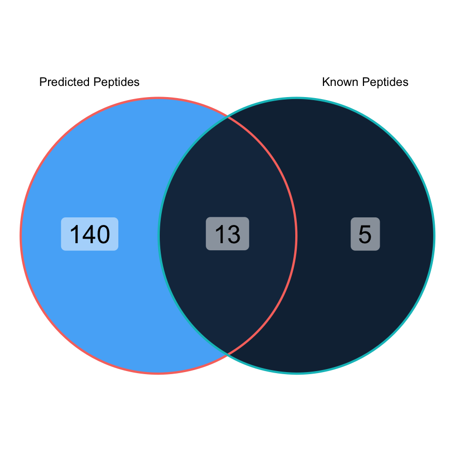

```r
spike_peps_vector <- as.vector(unique(spike_peps$pep_stim))

ggVennDiagram(x = list(spike_peps_vector, a2_spike_peps),
              category.names = c("Predicted Peptides", "Known Peptides"),
              set_size = 2,
              label = "count") +
              theme(legend.position = "none")
```

13 of 18 known peptides epitopes are detected using standard parameters. An additional 140 peptide epitopes are also predicted. The remaining 5 peptide epitopes can be detected by increasing the threshold filters, however, this will also increase the likelihood of false-positive peptide prediction.

## 5. Next we apply the mutations in omicron spike protein as previously described (D’Arminio) to generate the Omicron spike amino acid sequence.

```r
omicron_spike <- spike

str_sub(omicron_spike, 67, 67) <- "V"
str_sub(omicron_spike, 95, 95) <- "I"
str_sub(omicron_spike, 145, 145) <- "D"
str_sub(omicron_spike, 212, 212) <- "I"
str_sub(omicron_spike, 339, 339) <- "D"
str_sub(omicron_spike, 371, 371) <- "L"
str_sub(omicron_spike, 373, 373) <- "P"
str_sub(omicron_spike, 375, 375) <- "F"
str_sub(omicron_spike, 417, 417) <- "N"
str_sub(omicron_spike, 440, 440) <- "K"
str_sub(omicron_spike, 446, 446) <- "S"
str_sub(omicron_spike, 477, 477) <- "N"
str_sub(omicron_spike, 478, 478) <- "K"
str_sub(omicron_spike, 484, 484) <- "A"
str_sub(omicron_spike, 493, 493) <- "R"
str_sub(omicron_spike, 496, 496) <- "S"
str_sub(omicron_spike, 498, 498) <- "R"
str_sub(omicron_spike, 501, 501) <- "Y"
str_sub(omicron_spike, 505, 505) <- "H"
str_sub(omicron_spike, 547, 547) <- "K"
str_sub(omicron_spike, 614, 614) <- "G"
str_sub(omicron_spike, 655, 655) <- "Y"
str_sub(omicron_spike, 679, 679) <- "K"
str_sub(omicron_spike, 681, 681) <- "H"
str_sub(omicron_spike, 764, 764) <- "K"
str_sub(omicron_spike, 796, 796) <- "Y"
str_sub(omicron_spike, 856, 856) <- "K"
str_sub(omicron_spike, 954, 954) <- "H"
str_sub(omicron_spike, 969, 969) <- "K"
str_sub(omicron_spike, 981, 981) <- "F"

str_sub(omicron_spike, 214, 214) <- "EPER"

str_sub(omicron_spike, 211, 212) <- ""
str_sub(omicron_spike, 141, 144) <- ""
str_sub(omicron_spike, 69, 70) <- ""
```

## 6. Use the mhcI function to determine what peptides from spike protein are predicted to be presented on HLA*02:01

```r
omicron_spike_peps <- mhcI(ag_present = "HLA-A*02:01", ag_stim = omicron_spike)
```

## 7. Look at overlap between predecessor spike and omicron spike peptides

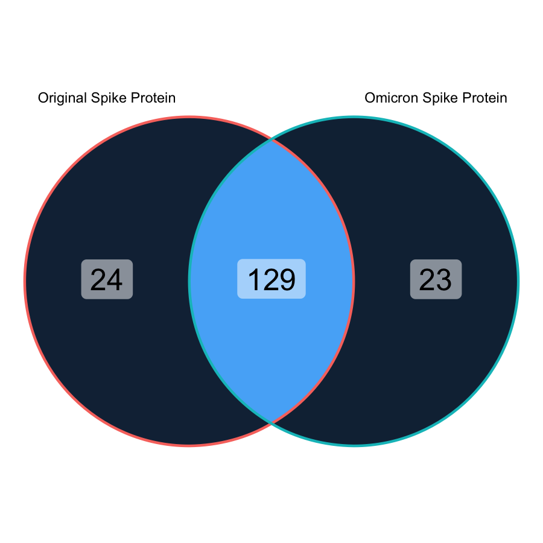

```r
omicron_peps_vector <- as.vector(unique(omicron_spike_peps$pep_stim))


ggVennDiagram(x=list(spike_peps_vector, omicron_peps_vector),
              category.names= c("Original Spike Protein", "Omicron Spike Protein"),
              set_size = 2,
              label="count") +
              theme(legend.position = "none")
```

### 8. It looks like the original spike protein had 24 peptides predicted that are no longer predicted as binders for the Omicron spike protein. Let’s check to see if any of these are the known A2 peptide epitopes.

```r
spike_peps %>%
  filter(!pep_stim %in% omicron_spike_peps$pep_stim) %>%
  filter(pep_stim %in% a2_spike_peps)
```

```
#> # A tibble: 2 × 12
#>   allele start   end length pep_s…¹ antigen ic50  perce…² stren…³ stren…⁴ method
#>   <chr>  <dbl> <dbl>  <dbl> <chr>   <chr>   <chr> <chr>   <chr>   <chr>   <chr>
#> 1 HLA-A…   417   425      9 KIADYN… spike   36.1  ""      strong  ""      ann
#> 2 HLA-A…   976   984      9 VLNDIL… spike   33.6  ""      strong  ""      ann
#> # … with 1 more variable: ag_type <chr>, and abbreviated variable names
#> #   ¹pep_stim, ²percentile_rank, ³strength_ic50, ⁴strength_rank
```

## Looks like two of the known epitopes have been mutated. Here we can look at the sequence of Omicron to see what mutations led to this

### data prep

```r
#* 1. load libraries *#
library(msa) # library to for alignment plots
library(Biostrings) # library for AAStringSet
library(here) # path to save plots

#* 2. check s417 and 976 *#
# The K-> N mutation at 417 keeps this peptide from being a strong binder
s417 <- substr(spike, 417, 425) # "KIADYNYKL"

# The L->F mutation at 981 alters this peptide's binding ability
s976 <- substr(spike, 976, 984) # "VLNDILSRL"

#* 3. align spike and omicron_spike *#
seq_in <- AAStringSet(c(spike,  omicron_spike))
names(seq_in) <- c("spike", "omicron_spike")
aln <- msa(seq_in, type = "protein", order = "input")

# pull out aligned sequences
spk_algn <- aln@unmasked$spike %>% as.character()
omc_algn <- aln@unmasked$omicron_spike %>% as.character()

#* 4. find locations of s417 and s976*#
s417_st <- str_locate(spk_algn, s417)[1,1]
s417_ed <- str_locate(spk_algn, s417)[1,2]
s417 == str_sub(omc_algn, s417_st, s417_ed)
s417_algn <- str_sub(spk_algn, s417_st, s417_ed)

s976_st <- str_locate(spk_algn, s976)[1,1]
s976_ed <- str_locate(spk_algn, s976)[1,2]
s976 == str_sub(spk_algn, s976_st, s976_ed)
s976_algn <- str_sub(spk_algn, s976_st, s976_ed)

#* 5. pull out sub_sequence starting from s417 and ending at s976 *#
spk_algn <- str_sub(spk_algn, s417_st,  s976_ed)
omc_algn <- str_sub(omc_algn, s417_st,  s976_ed)

#* 6. add - to s417 and s976 to make them have same length with aligned sub spike and sub omicron-spike *#
s417_n <- nchar(omc_algn) - nchar(s417_algn)
s417_algn <- paste0(s417_algn, strrep("-", s417_n))

s976_n <- nchar(omc_algn) - nchar(s976_algn)
s976_algn <- paste0(strrep("-", s976_n), s976_algn)

#* 6. put all sub-sequences into one AAStringSet and plot *#
seq4plot <- AAStringSet(c(spk_algn, omc_algn, s417_algn, s976_algn))
names(seq4plot) <- c("spik", "omicron_spike", "s417", "s976")

# fake sub alignment
aln4plot <- as(AAMultipleAlignment(seq4plot),
               "MsaAAMultipleAlignment")

fn <- "s417_"
seq_pos <- c(1,9)

fn <- "s976_"
seq_pos <- c(nchar(s976_algn)-9+1,nchar(s976_algn))

fn <- "s417_s976_"
seq_pos <- c(1,nchar(s976_algn))

## create PDF file according to some custom settings

PlotAlgn <- function(fl_nm, seq_nm, pos) {
  tmpFile <- tempfile(pattern=fl_nm,
                      tmpdir=here(),
                      fileext=".pdf")

  msaPrettyPrint(seq_nm,
                 pos,
                 file = tmpFile,
                 output = "pdf",
                 showNames = "left",
                 showNumbering = "right",
                 showLogo = "top",
                 showConsensus = "bottom",
                 logoColors = "rasmol",
                 verbose = FALSE,
                 askForOverwrite = FALSE,
                 showLegend = FALSE)
}

PlotAlgn(fl_nm = "s417_",
         seq_nm = aln4plot,
         pos = c(1,9))

PlotAlgn(fl_nm = "s976_",
         seq_nm = aln4plot,
         pos = c(nchar(s976_algn)-9+1, nchar(s976_algn)))

PlotAlgn(fl_nm = "s417_s976_",
         seq_nm = aln4plot,
         pos = c(1, nchar(s976_algn)))
```

### alignment plots

```r
knitr::include_graphics(system.file("extdata/vgn/plot/covid_s417.pdf",
                                    package = "epitopeR"))
```

[figure not shown]

```r
knitr::include_graphics(system.file("extdata/vgn/plot/covid_s976.pdf",
                        package = "epitopeR"))
```

[figure not shown]

For those interested in this question, this manuscript has done an excellent job of elaborating the details of the WT->Omicron spike response. Naranbhai V, Nathan A, Kaseke C, Berrios C, Khatri A, Choi S, Getz MA, Tano-Menka R, Ofoman O, Gayton A, Senjobe F, Zhao Z, St Denis KJ, Lam EC, Carrington M, Garcia-Beltran WF, Balazs AB, Walker BD, Iafrate AJ, Gaiha GD. T cell reactivity to the SARS-CoV-2 Omicron variant is preserved in most but not all individuals. Cell. 2022 Mar 17;185(6):1041-1051.e6. doi: 10.1016/j.cell.2022.01.029. Epub 2022 Feb 3. Erratum in: Cell. 2022 Mar 31;185(7):1259. PMID: 35202566; PMCID: PMC8810349.

#Additional References 1. Spike protein sequence:[Uniprot](https://www.uniprot.org/uniprotkb/P0DTC2/entry) 2. A02:01 binding peptides: [Shomuradova 2020, Immunity, PMC7664363](https://www.ncbi.nlm.nih.gov/pmc) and [Immudex](https://www.immudex.com/media/1535/tf119203-published-list-of-covid-19-t-cell-epitopes.pdf) 3. Mutations in spike for Omicron - [D’Arminio 2022, Molecules](https://doi.org/10.3390/molecules27154827)